# Jailene’s Final Project Part 1

Jailene Gonzalez

2022-12-06

# R Reference Guide

## Loading Data and Packages

### Loading Packages

There are two ways to load packages in R/RStudio:

- The function `library()` allows you to load the R packages that you want to analyze using R/RStudio. It also prints out an error message if it cannot find the package you are trying to load during the time you are running this function’s line of code.
- The function `require()` is another alternative way to load the R packages that you want to analyze using R/RStudio. Unlike the `library()` function, the `require()` function returns a logical value when a package is found (e.g. TRUE) and when it is not found (e.g. FALSE). It also prints out a warning when it cannot find the package you’re loading.

Here, I will show how you how to use these functions by loading the `here` and `palmerpenguins` packages.

```r
# Loading here package
library(here)
require(here)

# Loading palmerpenguins package
library(palmerpenguins)
require(palmerpenguins)
```

### Loading Data

In terms of loading your data, there are two functions that you can use together in base R to read and load your data:

- The function `here()` helps R navigate to the location that the file you are trying to use is at.
- The function `read.csv()` aids R in reading and transcribing the .csv file located in your Rproject folder into a `data.frame`.

Here’s an example using the `here()` and `read.csv()` functions to create a `data.frame` called `ginkgo` using a .csv file that contains some data collected from Ginkgo trees at UMass Amherst in 2022:

```r
# Creating `ginkgo` data.frame using here() and read.csv()
ginkgo <- read.csv(here("./docs/ginkgo_data_2022.csv"))
```

## Data structures

### Using `c()`:

The function `c()` combines or concatenates its arguments into a vector (a 1-dimensional data structure consisting of 1 or more elements).

All of the elements must be of the same type. I can’t combine character and numeric types in the same call to `c()`

Here’s two examples using numeric and character data types:

```r
## Create a vector of numbers:
num_vec  = c(1, 4, 8, 9, 13)

## Create a vector of characters:
char_vec = c("a", "fish", "data is cool")
```

I can show the contents of a vector by typing the name of the vector, or using the `print()` function.

```r
## Typing the name of the vector into the console prints the contents
num_vec
```

```
## [1]  1  4  8  9 13
```

```r
## The print() function accomplishes the same task:
print(char_vec)
```

```
## [1] "a"            "fish"         "data is cool"
```

### Using `length()`

The function `length()` is commonly used on vectors, factors, and other R objects in order to get or set its length.

This function can be used in two ways:

- `length(x)` - This line of code should get the length of your R object. The `x` here is the R object I want to find the length of.

```r
# Creating an R object called 'x' with 5 numbers.
x = c(4,5,6,7,8)

# Using length() to get the length of my R object 'x'.
length(x)
```

```
## [1] 5
```

- `length(x) <- value` - This line of code should set a new length to your R object. The `value` you input should be a non-negative integer or double.

```r
# Using 'length(x) <- value' and setting 'x' length from 5 to 3.
length(x) <- 3

# Calling 'x' to see the length I set by adding '<- 3' after length(x).
x
```

```
## [1] 4 5 6
```

### Using `matrix()`

The function `matrix()` generates a matrix from the given set of values you set.

Here is an example using the basic syntax for matrices. * `matrix(data, nrow, ncol, byrow, dimnames)`

```r
# Creating the matrix
my_matrix <- matrix(c(1:12), nrow = 4, byrow = TRUE)
print(my_matrix)
```

```
##      [,1] [,2] [,3]
## [1,]    1    2    3
## [2,]    4    5    6
## [3,]    7    8    9
## [4,]   10   11   12
```

### Using `data.frame()`

The function `data.frame()` creates a data frame, a list of variables of the same number of rows and row names that were given inside the class `data.frame()`.

```r
school_data_frame <- data.frame(
  student_id = c(1:7),
  student_name = c("Adri","Billie","Jailene","Jaylene", "Junior","Lissete","Oscar")
)

# Calling new data.frame
school_data_frame
```

```
##   student_id student_name
## 1          1         Adri
## 2          2       Billie
## 3          3      Jailene
## 4          4      Jaylene
## 5          5       Junior
## 6          6      Lissete
## 7          7        Oscar
```

### Using `nrow()`

The function `nrow()` returns the number of rows that are present inside of your vector, array, data frame, or NULL. The value of this function is an integer of length 1 or NULL.

```r
# Using the nrow() function to get the number of rows from the data frame 'ginkgo'

nrow(ginkgo)
```

```
## [1] 220
```

### Using `ncol()`

The function `ncol()` returns the number of columns that are present inside of your vector, array, data frame, or NULL. The value of this function is an integer of length 1 or NULL.

```r
# Using the ncol() function to get the number of columns from the data frame 'ginkgo'

ncol(ginkgo)
```

```
## [1] 6
```

### Using `dim()`

The function `dim()` aids the R user in retrieving or setting the dimensions of an object. It is usually used as a method for `data.frames`.

In the example below, you should see that dim returns the number of rows and columns for the data frame ‘ginkgo’.

```r
# Using dim() function on 'ginkgo' data frame
dim(ginkgo)
```

```
## [1] 220   6
```

## Subsetting

### Using the `$` operator

The operator `$` is used to access, extract, and subset a specific part of a data object in R, e.g. a column from a data frame or list.

Below, I will show an example using `$` to extract the information of one column from the `ginkgo` trees data frame.

```r
# Using `$` to subset the petiole_length column from the `ginkgo` data frame.

ginkgo$petiole_length
```

```
##   [1]  91  56  71  44  40  50  82  84  70  40  70  88  43  59  42  49  71  85
##  [19]  35  75  54  50  33  36  42  31  67  54  71  71  36  22  47  37  58  25
##  [37]  60  65  45  48  82  63  97  81  70  70  75  54  60  37  33  57 100  32
##  [55]  76  25  50  43  79  93  90  75  36  36  45  76  32  62  69  49  58  71
##  [73]  54  49  55  84  69  73  62  45  62  50  30  80  58  50  65  56  50  53
##  [91]  58  71 100  86 102  73  71  83  84  77  65 100  54  51  70  53  62  61
## [109]  72 103 106  85  92 114  82  92 126 104  96  52  51  53  57  46  69  57
## [127]  41  58  77  55  67  42  75  50  76  60  71  64  58  55  45  79  62  39
## [145]  50  39  53  62  45  40  26  79  38  53  50  51  59  30  63  65  41  53
## [163]  56  58  45  67  53  32  50  69  45  72  55  27  62  76  41  37  43  57
## [181]  51  63  68  66  46  93  52  48  69  68  70  61  25  21  30  25  43  18
## [199]  30  13  62  28  67  75  68  86  55  94  79  19  61  22  23  73  70  14
## [217]  69 113 111  31
```

### Using the `[]` operator

The operator `[]` allows you to subset a column or row. Below I will show various ways that you can use this operator.

Example #1: Here we will subset the first row inside of the `ginkgo` data frame.

```r
#Subsetting the first row of the `ginkgo` data frame
ginkgo_1_subset <- ginkgo[1,]
```

Example #2: Here we will select the content from row 2 and column 3 that is in the `ginkgo` data frame.

```r
#Selecting the content from row 2 and column 3
ginkgo_2_subset <- ginkgo[2,3]
```

Example #3: Here we will select the third column from the `ginkgo` data frame.

```r
# Selecting the third column from the ginkgo data
ginkgo_3_subset <- ginkgo[,3]
```

### Using the `subset()` function

The function `subset()` helps return subsets of vectors, matrices or data frames based on the conditions one sets.

Here’s an example where I only subset the species `Adelie` from the `penguins` data frame (which is included in the `palmerpenguins` R package).

```r
# Subsetting to get Adelie Penguin Data
adelie <- subset(penguins, species == "Adelie")
```

## Numerical Data Exploration

### Using the `summary()` Function

The function `summary()` produces a result summary table derived from results of various model fitting functions, i.e. minimum/maximum value, 1st/3rd quartile, median, and mean.

Here’s an example where I used the `summary()` function on the `ginkgo` data frame for the variable `petiole_length`.

```r
# Summary of `petiole_length` in `ginkgo` data frame
summary(ginkgo$petiole_length)
```

```
##    Min. 1st Qu.  Median    Mean 3rd Qu.    Max.
##   13.00   45.00   58.00   59.51   71.00  126.00
```

### Using the `mean()` Function

The function `mean()` takes the arithmetic mean (also known as the average) of the R object you want.

Down below, I provide an example where I take the mean of the variable `petiole_length` from the `ginkgo` data frame.

```r
# Mean of `petiole_length` in `ginkgo` data frame
mean(ginkgo$petiole_length)
```

```
## [1] 59.50909
```

### Using the `sd()` Function

The function `sd()` takes the standard deviation of the values in a numeric vector or an R object (except if its a factor coercible to a numeric by `as.double(x)`).

```r
# Standard deviation of `petiole_length` in `ginkgo` data frame
sd(ginkgo$petiole_length)
```

```
## [1] 21.04778
```

## Graphical Data Exploration

### How to create a scatter`plot`

The function `plot()` allows you to create the data visualization, scatterplot, given the information from your data frame.

- `col =` changes the color of the points
- `pch =` changes the shape of the points
- `cex =` changes the size of the points
- `main =` adds a title to your visualization (note: you have to write your title inside of quotation marks, e.g. main = “your title here”)
- `xlab =` adds/changes the x-axis label of your visualization (note: this label is written inside of quotation marks)
- `ylab =` adds/changes the y-axis label of your visualization (note: this label is written inside of quotation marks)
- `xlim =` specifies the x-axis limits of your plot
- `ylim =` specifies the y-axis limits of your plot

Here we used the `ginkgo` data frame to create a scatterplot of max leaf depth (x) and max leaf width (y).

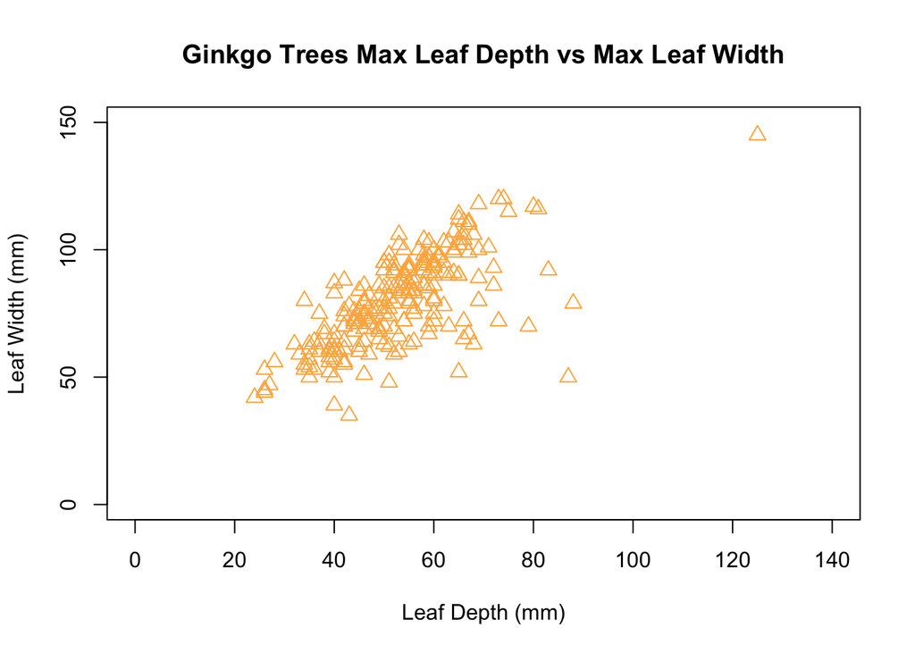

```r
plot(ginkgo$max_depth, ginkgo$max_width,
     col = "#feb24c",
     pch = 2,
     cex = 1.25,
     main = "Ginkgo Trees Max Leaf Depth vs Max Leaf Width",
     xlab = "Leaf Depth (mm)",
     ylab = "Leaf Width (mm)",
     xlim = c(0, 140),
     ylim = c(0, 150))
```

### How to create a `hist`ogram

The function `hist()` creates a histogram. This type of plot only requires an x variable to make the plot. Note: when making a histogram you can also use `breaks =` to change the number of cells displayed in your data visualization.

Here’s an example using the function `hist` and the element `breaks` to create a histogram of penguins flipper lengths.

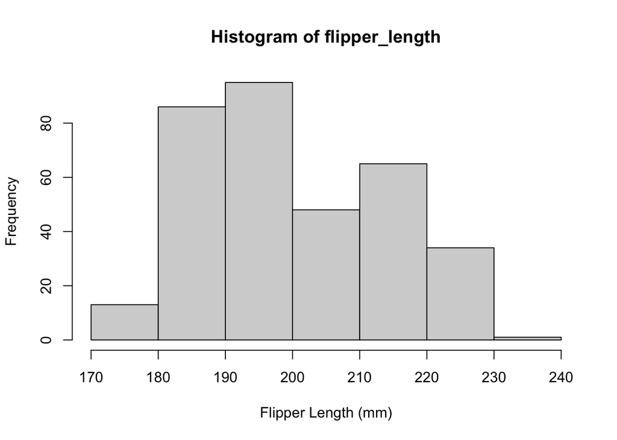

```r
# Creating a histogram of penguins flipper lengths
flipper_length <- penguins$flipper_length_mm
hist(flipper_length,
     breaks = 5,
     xlab = "Flipper Length (mm)")
```

### How to create a `boxplot`

The function `boxplot` creates a boxplot using one variable.

Here’s an example of a simple boxplot I made showing the petiole lengths of Ginkgo Tree leaves.

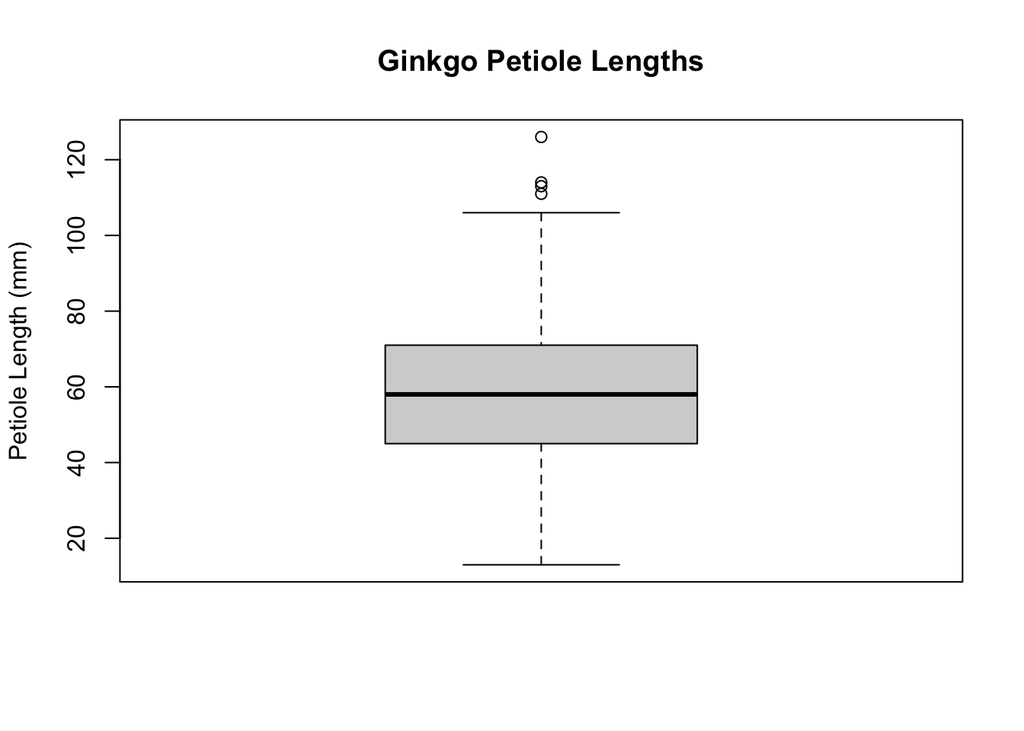

```r
# Simple Boxplots -- petiole lengths
boxplot(ginkgo$petiole_length,
        main = "Ginkgo Petiole Lengths",
        ylab = "Petiole Length (mm)")
```

Here’s an example of another kind of boxplot that you can make that looks into multiple variables.

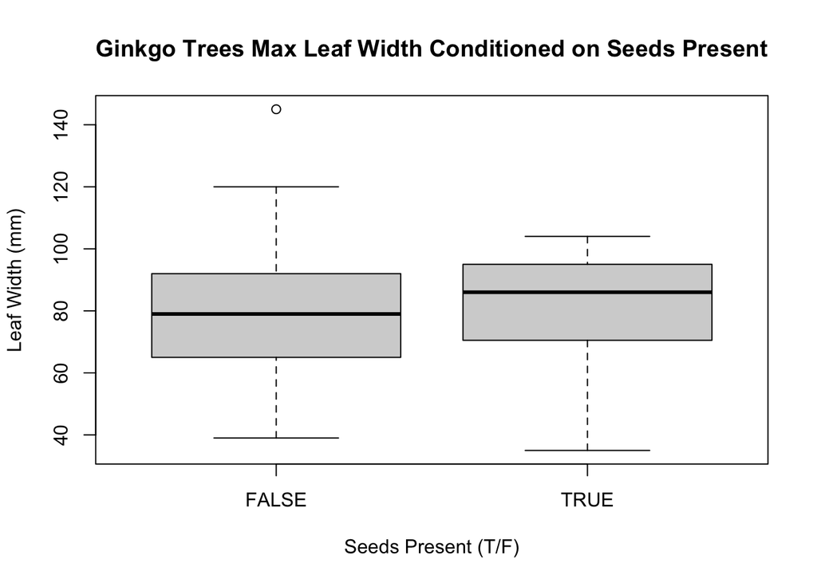

```r
# Conditional Boxplots -- of max leaf width conditioned on the seeds_present column

boxplot(max_width~seeds_present,
        data = ginkgo,
        main = "Ginkgo Trees Max Leaf Width Conditioned on Seeds Present",
        xlab = "Seeds Present (T/F)",
        ylab = "Leaf Width (mm)")
```

### How to create a multi-panel figure

To create a multi-panel figure, you can use the function `par()` with its required argument `mfrow`. The combination of `par(mfrow = c())` allows the R user to set the parameters (the number of rows and columns) for their panel.

Here’s an example of a 2 by 2 grid panel, showing 4 histograms from the `ginkgo` data frame.

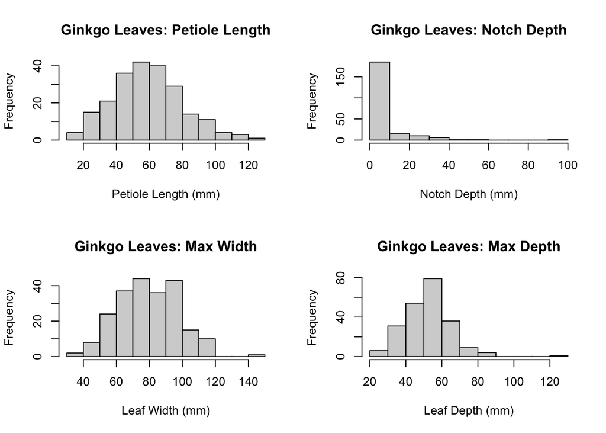

```r
#Setting the panel's parameters
par(mfrow= c(2,2))

# petiole length histogram
hist(ginkgo$petiole_length,
     main = "Ginkgo Leaves: Petiole Length",
     xlab = "Petiole Length (mm)")

# notch depth histogram
hist(ginkgo$notch_depth,
     main = "Ginkgo Leaves: Notch Depth",
     xlab = "Notch Depth (mm)")

# max leaf width histogram
hist(ginkgo$max_width,
     main = "Ginkgo Leaves: Max Width",
     xlab = "Leaf Width (mm)")

# max leaf depth histogram
hist(ginkgo$max_depth,
     main = "Ginkgo Leaves: Max Depth",
     xlab = "Leaf Depth (mm)")
```

## Distribution Functions

### Using the `dnorm()` function

The `dnorm()` function returns the value of the probability density function of the normal distribution given a set of conditions. These conditions are a random variable (x), a population mean, and a population standard deviation.

Here’s an example using `dnorm`.

```r
# Using dnorm on a random variable (x = 3), with a mean of 0 and standard deviation of 1

dnorm(x=3, mean=0, sd=1)
```

```
## [1] 0.004431848
```

### Using the `pnorm()` function

The `pnorm()` function returns the value of the cumulative density function of the normal distribution given a set of conditions. These conditions are a random variable (q), a population mean, and a standard deviation.

Here’s an example using `pnorm`.

```r
# using pnorm on a vector of quantiles of 100 with a mean of 50 and standard deviation of 1

pnorm(100, mean=50, sd=1, lower.tail=FALSE)
```

```
## [1] 0
```

### Using the `qnorm()` function

The `qnorm()` function returns the value of the cumulative density function of the normal distribution given a set of conditions. These conditions are a random variable (p), a population mean, and a standard deviation.

Here’s an example using `qnorm`:

```r
# Using qnorm given the 95th quantile
qnorm(.95, mean=0, sd=1)
```

```
## [1] 1.644854
```

### Using the `dbinom()` function

The `dbinom()` function returns the value of the probability density function of the binomial distribution given a set of conditions. These conditions are a random variable (x), the number of trials (size), and the probability of success for each trial.

Here’s an example using `dbinom()`.

```r
# Using `dbinom` on a sample size of 80 and probability of 50%

dbinom(x=20, size=80, prob=.5)
```

```
## [1] 2.924345e-06
```

### Using the `pbinom()` function

The `pbinom()` function returns the value of the cumulative density function of the binomial distribution given a set of conditions. These conditions are a random variable (q), the number of trials (size), and the probability of success for each trial.

Here’s an example using `pbinom()`.

```r
# Using `pbinom` on a sample size of 100 and probability of 50%

pbinom(10, size=100, prob=.5, lower.tail=FALSE)
```

```
## [1] 1
```

### Using the `qbinom()` function

The `qbinom()` function returns the value of the cumulative density function of the binomial distribution given a set of conditions. These conditions are a random variable (p), the number of trials (size), and the probability of success for each trial.

Here’s an example using `qbinom()`.

```r
# Using `qbinom` on a sample size of 450 and probability of 75%

qbinom(0.49, size=450, prob=.75)
```

```
## [1] 337
```

…